# HYPOTHYROID DETECTION

## Objective :

Prepare the dataset for analysis, using methods learnt and researched independently, including but not limited to Missing Value Imputation, Outlier Detection etc. Find out your observations on different variables using descriptive statistics, Visualization etc. Report if there is any pattern present in the data.

Apply a Classification algorithm using ‘binaryClass’ column as target variable. Compare all models using various performance metrics. Provide all inferences of your findings.

#### Import Important Libraries

```python
import pandas as pd
import numpy as np
import matplotlib.pyplot as plt
import seaborn as sns
import math
```

```python
import warnings
warnings.filterwarnings('ignore')
```

#### Loading of dataset

```python
df = pd.read_csv("hypothyroid_classification.csv")
df
```

|  | age | sex | on thyroxine | query on thyroxine | on antithyroid medication | sick | pregnant | thyroid surgery | I131 treatment | query hypothyroid | ... | TT4 measured | TT4 | T4U measured | T4U | FTI measured | FTI | TBG measured | TBG | referral source | binaryClass |
| --- | --- | --- | --- | --- | --- | --- | --- | --- | --- | --- | --- | --- | --- | --- | --- | --- | --- | --- | --- | --- | --- |
| 0 | 41 | F | f | f | f | f | f | f | f | f | ... | t | 125 | t | 1.14 | t | 109 | f | ? | SVHC | P |
| 1 | 23 | F | f | f | f | f | f | f | f | f | ... | t | 102 | f | ? | f | ? | f | ? | other | P |
| 2 | 46 | M | f | f | f | f | f | f | f | f | ... | t | 109 | t | 0.91 | t | 120 | f | ? | other | P |
| 3 | 70 | F | t | f | f | f | f | f | f | f | ... | t | 175 | f | ? | f | ? | f | ? | other | P |
| 4 | 70 | F | f | f | f | f | f | f | f | f | ... | t | 61 | t | 0.87 | t | 70 | f | ? | SVI | P |
| ... | ... | ... | ... | ... | ... | ... | ... | ... | ... | ... | ... | ... | ... | ... | ... | ... | ... | ... | ... | ... | ... |
| 3767 | 30 | F | f | f | f | f | f | f | f | f | ... | f | ? | f | ? | f | ? | f | ? | other | P |
| 3768 | 68 | F | f | f | f | f | f | f | f | f | ... | t | 124 | t | 1.08 | t | 114 | f | ? | SVI | P |
| 3769 | 74 | F | f | f | f | f | f | f | f | f | ... | t | 112 | t | 1.07 | t | 105 | f | ? | other | P |
| 3770 | 72 | M | f | f | f | f | f | f | f | f | ... | t | 82 | t | 0.94 | t | 87 | f | ? | SVI | P |
| 3771 | 64 | F | f | f | f | f | f | f | f | f | ... | t | 99 | t | 1.07 | t | 92 | f | ? | other | P |

3772 rows × 30 columns

# details about the data given:

## Target Variable

binaryClass:

Type: Target / Label

Values: 'P' (Positive) or 'N' (Negative)

Meaning: Whether the patient has thyroid disorder or not.

Effect: The model's job is to predict this based on other features.

## Numerical Features

| Feature | Description | Effect on Thyroid Detection |
| --- | --- | --- |
| **Age** | Patient’s age | Thyroid issues are more common in older adults. |
| **TSH** | Thyroid Stimulating Hormone level | High → **hypothyroidism** Low → **hyperthyroidism** |
| **T3** | Triiodothyronine hormone level | Low → hypothyroidism; high → hyperthyroidism |
| **TT4** | Total thyroxine level | Similar to T3; indicates thyroid gland activity |
| **T4U** | Thyroxine uptake | Measures binding capacity of thyroxine-binding globulin |
| **FTI** | Free Thyroxine Index (TT4 / T4U) | Calculated value; more stable indicator of thyroid function |
| **TBG** | Thyroxine Binding Globulin | Often missing; rarely used directly |

## Binary Medical History / Condition Flags

| Feature | Meaning | Effect / Clinical Insight |
| --- | --- | --- |
| `on thyroxine` | Patient is on thyroid hormone medication | Likely has hypothyroidism |
| `query on thyroxine` | Doctor is considering prescribing thyroxine | May have suspected hypothyroidism |
| `on antithyroid medication` | Patient is on anti-thyroid meds (for hyperthyroidism) | Suggests hyperthyroidism |
| `sick` | Patient was sick during test | Can affect hormone levels temporarily |
| `pregnant` | Patient is pregnant | Affects hormone levels; can cause gestational thyroid issues |
| `thyroid surgery` | Had surgery on thyroid gland | Indicates past thyroid issues |
| `I131 treatment` | Radioactive iodine treatment | Common treatment for hyperthyroidism |
| `query hypothyroid` | Doctor suspects hypothyroidism | Potential class positive |
| `query hyperthyroid` | Doctor suspects hyperthyroidism | Can be either positive or borderline |
| `lithium` | Patient takes lithium | Lithium can impair thyroid function |
| `goitre` | Visible thyroid gland enlargement | Suggests thyroid dysfunction |
| `tumor` | Related tumor presence | May disrupt hormone regulation |
| `hypopituitary` | Problem with pituitary gland | Can cause secondary hypothyroidism |
| `psych` | Psychological disorders | May affect interpretation of symptoms |

## Measurement Indicator Flags

These indicate whether the hormone test values were measured or missing.

| Feature | Meaning | Effect |
| --- | --- | --- |
| `TSH measured` | Was TSH measured? (`t` or `f`) | Helps handle missing |
| `T3 measured` | Was T3 measured? |  |
| `TT4 measured` | Was TT4 measured? |  |
| `T4U measured` | Was T4U measured? |  |
| `FTI measured` | Was FTI calculated or available? |  |
| `TBG measured` | Was TBG measured? | Often missing |

If a value is not measured (i.e., flag = f), its corresponding hormone column may be NaN. Use these flags to decide whether to drop or impute the value.

## Administrative / Source Feature

#### referral source:

**Meaning**: Where the patient was referred from — e.g., "SVHC", "other", etc.

**Effect**: Can show **systematic bias** in patient types (e.g., hospital vs clinic).

## Summary Table of Feature Categories

| Category | Features |
| --- | --- |
| **Target** | `binaryClass` |
| **Numerical** | `age`, `TSH`, `T3`, `TT4`, `T4U`, `FTI`, `TBG` |
| **Binary Health Flags** | `on thyroxine`, `query on thyroxine`, ..., `psych` |
| **Measurement Flags** | `TSH measured`, `T3 measured`, ..., `TBG measured` |
| **Source Info** | `referral source` |

# Understanding the Data

### Target Column

**binaryClass**: Likely the label (e.g., 'P' for positive thyroid disorder, 'N' for negative/normal).

### Feature Types

**Categorical Features:** Columns: sex, on thyroxine, query on thyroxine, etc. Format: Mostly yes/no in 't' (true) or 'f' (false) format.

**Numerical Features (stored as objects):** Columns: age, TSH, T3, TT4, T4U, FTI, etc. Notes: Require conversion from strings to numeric types and handling of missing values (represented as '?').

**Redundant Flags:** Columns: T3 measured, T4U measured, etc. Purpose: May indicate whether the corresponding test result is valid or missing.

# Removal of duplicate rows

```python
 # info about the dataframe
df.info()
```

```
<class 'pandas.core.frame.DataFrame'>
RangeIndex: 3772 entries, 0 to 3771
Data columns (total 30 columns):
 #   Column                     Non-Null Count  Dtype
---  ------                     --------------  -----
 0   age                        3772 non-null   object
 1   sex                        3772 non-null   object
 2   on thyroxine               3772 non-null   object
 3   query on thyroxine         3772 non-null   object
 4   on antithyroid medication  3772 non-null   object
 5   sick                       3772 non-null   object
 6   pregnant                   3772 non-null   object
 7   thyroid surgery            3772 non-null   object
 8   I131 treatment             3772 non-null   object
 9   query hypothyroid          3772 non-null   object
```

[output cut: 22 more lines]

```python
# Drop duplicate rows keeping the first occurrence
df = df.drop_duplicates(keep='first')

# To verify the operation
print(f"Number of rows after removing duplicates: {len(df)}")
```

```
Number of rows after removing duplicates: 3711
```

# Missing value detection

```python
 # missing values across the columns
df.isna().sum()
```

```
age                          0
sex                          0
on thyroxine                 0
query on thyroxine           0
on antithyroid medication    0
sick                         0
pregnant                     0
thyroid surgery              0
I131 treatment               0
query hypothyroid            0
query hyperthyroid           0
lithium                      0
goitre                       0
tumor                        0
hypopituitary                0
psych                        0
TSH measured                 0
TSH                          0
T3 measured                  0
T3                           0
TT4 measured                 0
TT4                          0
T4U measured                 0
T4U                          0
FTI measured                 0
FTI                          0
TBG measured                 0
TBG                          0
referral source              0
binaryClass                  0
dtype: int64
```

It is showing that there is no missing value present in the data set and we found out that in some places '?' is present instead of value. Now we will consider those as the missing values and now we will treat this

```python
# Replace '?' with NaN (if applicable)
df.replace('?', pd.NA, inplace=True)

# Count of missing values per column
df.isna().sum()
```

```
age                             1
sex                           149
on thyroxine                    0
query on thyroxine              0
on antithyroid medication       0
sick                            0
pregnant                        0
thyroid surgery                 0
I131 treatment                  0
query hypothyroid               0
query hyperthyroid              0
lithium                         0
goitre                          0
tumor                           0
hypopituitary                   0
psych                           0
TSH measured                    0
TSH                           309
T3 measured                     0
T3                            709
TT4 measured                    0
TT4                           171
T4U measured                    0
T4U                           327
FTI measured                    0
FTI                           325
TBG measured                    0
TBG                          3711
referral source                 0
binaryClass                     0
dtype: int64
```

There are a lot of missing value present in columns

# Dimensionality reduction due to high missing value ratio and low variance filter

There is a variable named TBG which have missing value in all rows . It should be dropped . Because From the data set we observed that the variable TBG has all rows as false. it shows the low variance so if we drop it then it won't cause any loss of information

```python
df = df.drop('TBG measured', axis=1)
df = df.drop('TBG', axis=1)
df.head()
```

|  | age | sex | on thyroxine | query on thyroxine | on antithyroid medication | sick | pregnant | thyroid surgery | I131 treatment | query hypothyroid | ... | T3 measured | T3 | TT4 measured | TT4 | T4U measured | T4U | FTI measured | FTI | referral source | binaryClass |
| --- | --- | --- | --- | --- | --- | --- | --- | --- | --- | --- | --- | --- | --- | --- | --- | --- | --- | --- | --- | --- | --- |
| 0 | 41 | F | f | f | f | f | f | f | f | f | ... | t | 2.5 | t | 125 | t | 1.14 | t | 109 | SVHC | P |
| 1 | 23 | F | f | f | f | f | f | f | f | f | ... | t | 2 | t | 102 | f | <NA> | f | <NA> | other | P |
| 2 | 46 | M | f | f | f | f | f | f | f | f | ... | f | <NA> | t | 109 | t | 0.91 | t | 120 | other | P |
| 3 | 70 | F | t | f | f | f | f | f | f | f | ... | t | 1.9 | t | 175 | f | <NA> | f | <NA> | other | P |
| 4 | 70 | F | f | f | f | f | f | f | f | f | ... | t | 1.2 | t | 61 | t | 0.87 | t | 70 | SVI | P |

5 rows × 28 columns

```python
# List of numerical columns (from dataset description)
num_cols = ['age', 'TSH', 'T3', 'TT4', 'T4U', 'FTI']

# Convert numerical columns to float
for col in num_cols:
    df[col] = pd.to_numeric(df[col], errors='coerce')

# Remove all-NaN columns from num_cols for imputation
num_cols_clean = [col for col in num_cols if not df[col].isnull().all()]
print("Numerical columns used for imputation:", num_cols_clean)

# Identify categorical columns (exclude target and numerical columns)
cat_cols = [col for col in df.columns if col not in num_cols and col != 'binaryClass']
print("Categorical columns:", cat_cols)
```

```
Numerical columns used for imputation: ['age', 'TSH', 'T3', 'TT4', 'T4U', 'FTI']
Categorical columns: ['sex', 'on thyroxine', 'query on thyroxine', 'on antithyroid medication', 'sick', 'pregnant', 'thyroid surgery', 'I131 treatment', 'query hypothyroid', 'query hyperthyroid', 'lithium', 'goitre', 'tumor', 'hypopituitary', 'psych', 'TSH measured', 'T3 measured', 'TT4 measured', '…
```

```python
# Converting the variables to suitable data types
```

```python
# Convert 'age', 'TT4', 'FTI' to nullable integer type (Int64, handles NaN)
df[['age', 'TT4', 'FTI']] = df[['age', 'TT4', 'FTI']].astype('float').round().astype('Int64')

# Convert 'TSH', 'T3', 'T4U' to float (NaN remains as NaN)
df[['TSH', 'T3', 'T4U']] = df[['TSH', 'T3', 'T4U']].astype(float)

# Verify the data types
print(df[['age', 'TT4', 'FTI', 'TSH', 'T3', 'T4U']].dtypes)
```

```
age      Int64
TT4      Int64
FTI      Int64
TSH    float64
T3     float64
T4U    float64
dtype: object
```

# Missing value treatment

```python
# Percentage of missing values per column
percentage_missing_rows = df.isna().any(axis=1).mean() * 100
print(f"{percentage_missing_rows:.2f}% of rows have missing values.\n")

columns_with_missing = df.columns[df.isna().any()].tolist()
print("Columns with missing values:")
print(columns_with_missing)
```

```
28.81% of rows have missing values.

Columns with missing values:
['age', 'sex', 'TSH', 'T3', 'TT4', 'T4U', 'FTI']
```

ow we will use MICE Treatment to treat the Missig values.

age -> discrete

sex -> categorical

TSH -> continuous

T3 -> continuous

TT4 -> discrete

T4U -> continuous

FTI -> discrete

# Imputation of MICE Treatment

```python
# List of numerical columns (from dataset description)
num_cols = ['age', 'TSH', 'T3', 'TT4', 'T4U', 'FTI']

# Convert numerical columns to float
for col in num_cols:
    df[col] = pd.to_numeric(df[col], errors='coerce')

# Remove all-NaN columns from num_cols for imputation
num_cols_clean = [col for col in num_cols if not df[col].isnull().all()]

# Identify categorical columns (exclude target and numerical columns)
cat_cols = [col for col in df.columns if col not in num_cols and col != 'binaryClass']

from sklearn.experimental import enable_iterative_imputer
from sklearn.impute import IterativeImputer, SimpleImputer

df_imputed = df.copy()

# MICE imputation for numericals
mice = IterativeImputer(random_state=42)
num_imputed = mice.fit_transform(df[num_cols_clean])
df_imputed[num_cols_clean] = num_imputed

# Fill all-NaN numerical columns with NaN (if any were dropped)
for col in num_cols:
    if col not in num_cols_clean:
        df[col] = np.nan

# Most frequent imputation for categoricals
cat_imputer = SimpleImputer(strategy='most_frequent')
df_imputed[cat_cols] = cat_imputer.fit_transform(df[cat_cols])

df_imputed.isna().sum()
```

```
age                          0
sex                          0
on thyroxine                 0
query on thyroxine           0
on antithyroid medication    0
sick                         0
pregnant                     0
thyroid surgery              0
I131 treatment               0
query hypothyroid            0
query hyperthyroid           0
lithium                      0
goitre                       0
tumor                        0
hypopituitary                0
psych                        0
TSH measured                 0
TSH                          0
T3 measured                  0
T3                           0
TT4 measured                 0
TT4                          0
T4U measured                 0
T4U                          0
FTI measured                 0
FTI                          0
referral source              0
binaryClass                  0
dtype: int64
```

We successfully imputed all the missing values.

# Outlier detection

```python
colsToCentreScale = df_imputed[['age', 'TSH', 'T3', 'TT4', 'T4U', 'FTI']]

df_scaled = df_imputed.copy()
for i in colsToCentreScale:
    df_scaled[i] = (df_imputed[i] - df_imputed[i].mean())/df_imputed[i].std()

df_scaled.head()
```

|  | age | sex | on thyroxine | query on thyroxine | on antithyroid medication | sick | pregnant | thyroid surgery | I131 treatment | query hypothyroid | ... | T3 measured | T3 | TT4 measured | TT4 | T4U measured | T4U | FTI measured | FTI | referral source | binaryClass |
| --- | --- | --- | --- | --- | --- | --- | --- | --- | --- | --- | --- | --- | --- | --- | --- | --- | --- | --- | --- | --- | --- |
| 0 | -0.539850 | F | f | f | f | f | f | f | f | f | ... | t | 0.615643 | t | 0.478652 | t | 0.776412 | t | -0.033499 | SVHC | P |
| 1 | -1.434425 | F | f | f | f | f | f | f | f | f | ... | t | -0.032332 | t | -0.182560 | f | 0.015984 | f | -0.217753 | other | P |
| 2 | -0.291357 | M | f | f | f | f | f | f | f | f | ... | f | -0.031439 | t | 0.018678 | t | -0.452353 | t | 0.308787 | other | P |
| 3 | 0.901411 | F | t | f | f | f | f | f | f | f | ... | t | -0.161927 | t | 1.916068 | f | 0.310901 | f | 1.845705 | other | P |
| 4 | 0.901411 | F | f | f | f | f | f | f | f | f | ... | t | -1.069092 | t | -1.361241 | t | -0.666051 | t | -1.247057 | SVI | P |

5 rows × 28 columns

```python
# Select numerical columns
numerical_cols = ['age', 'TSH', 'T3', 'TT4', 'T4U', 'FTI']
df_numerical = df[numerical_cols].copy()

# Calculate IQR bounds
Q1 = df_numerical.quantile(0.25)
Q3 = df_numerical.quantile(0.75)
IQR = Q3 - Q1
lower_bound = Q1 - 1.5 * IQR
upper_bound = Q3 + 1.5 * IQR

# Identify outlier rows (corrected parentheses)
outlier_rows = (
    (df_numerical < lower_bound) |
    (df_numerical > upper_bound)
).any(axis=1)

# Count total outlier rows
total_outlier_rows = outlier_rows.sum()

# Show outliers per column
outliers_per_column = (
    (df_numerical < lower_bound) |
    (df_numerical > upper_bound)
).sum()
print("\nOutliers per column:")
print(outliers_per_column)

print(f"\nTotal rows with at least one outlier: {total_outlier_rows}")
print("Percentage of outlier rows: ", total_outlier_rows/len(df)*100, "%")

df_imputed = df.copy()
```

```
Outliers per column:
age      1
TSH    400
T3     249
TT4    213
T4U    206
FTI    235
dtype: int64

Total rows with at least one outlier: 820
Percentage of outlier rows:  22.096469954190244 %
```

# Label encoding for variables with two classes

```python
df_scaled.isna().sum()
```

```
age                          0
sex                          0
on thyroxine                 0
query on thyroxine           0
on antithyroid medication    0
sick                         0
pregnant                     0
thyroid surgery              0
I131 treatment               0
query hypothyroid            0
query hyperthyroid           0
lithium                      0
goitre                       0
tumor                        0
hypopituitary                0
psych                        0
TSH measured                 0
TSH                          0
T3 measured                  0
T3                           0
TT4 measured                 0
TT4                          0
T4U measured                 0
T4U                          0
FTI measured                 0
FTI                          0
referral source              0
binaryClass                  0
dtype: int64
```

```python
df_scaled['sex'].replace(['F','M'],[1,0],inplace = True)
df_scaled['on thyroxine'].replace(['t','f'],[1,0],inplace = True)
df_scaled['query on thyroxine'].replace(['t','f'],[1,0],inplace = True)
df_scaled['on antithyroid medication'].replace(['t','f'],[1,0],inplace = True)
df_scaled['sick'].replace(['t','f'],[1,0],inplace = True)
df_scaled['pregnant'].replace(['t','f'],[1,0],inplace = True)
df_scaled['thyroid surgery'].replace(['t','f'],[1,0],inplace = True)
df_scaled['I131 treatment'].replace(['t','f'],[1,0],inplace = True)
df_scaled['query hypothyroid'].replace(['t','f'],[1,0],inplace = True)
df_scaled['query hyperthyroid'].replace(['t','f'],[1,0],inplace = True)
df_scaled['lithium'].replace(['t','f'],[1,0],inplace = True)
df_scaled['goitre'].replace(['t','f'],[1,0],inplace = True)
df_scaled['tumor'].replace(['t','f'],[1,0],inplace = True)
df_scaled['hypopituitary'].replace(['t','f'],[1,0],inplace = True)
df_scaled['psych'].replace(['t','f'],[1,0],inplace = True)
df_scaled['TSH measured'].replace(['t','f'],[1,0],inplace = True)
df_scaled['T3 measured'].replace(['t','f'],[1,0],inplace = True)
df_scaled['TT4 measured'].replace(['t','f'],[1,0],inplace = True)
df_scaled['T4U measured'].replace(['t','f'],[1,0],inplace = True)
df_scaled['FTI measured'].replace(['t','f'],[1,0],inplace = True)
df_scaled['binaryClass'].replace(['P','N'],[1,0],inplace = True)

df_scaled.head()
```

|  | age | sex | on thyroxine | query on thyroxine | on antithyroid medication | sick | pregnant | thyroid surgery | I131 treatment | query hypothyroid | ... | T3 measured | T3 | TT4 measured | TT4 | T4U measured | T4U | FTI measured | FTI | referral source | binaryClass |
| --- | --- | --- | --- | --- | --- | --- | --- | --- | --- | --- | --- | --- | --- | --- | --- | --- | --- | --- | --- | --- | --- |
| 0 | -0.539850 | 1 | 0 | 0 | 0 | 0 | 0 | 0 | 0 | 0 | ... | 1 | 0.615643 | 1 | 0.478652 | 1 | 0.776412 | 1 | -0.033499 | SVHC | 1 |
| 1 | -1.434425 | 1 | 0 | 0 | 0 | 0 | 0 | 0 | 0 | 0 | ... | 1 | -0.032332 | 1 | -0.182560 | 0 | 0.015984 | 0 | -0.217753 | other | 1 |
| 2 | -0.291357 | 0 | 0 | 0 | 0 | 0 | 0 | 0 | 0 | 0 | ... | 0 | -0.031439 | 1 | 0.018678 | 1 | -0.452353 | 1 | 0.308787 | other | 1 |
| 3 | 0.901411 | 1 | 1 | 0 | 0 | 0 | 0 | 0 | 0 | 0 | ... | 1 | -0.161927 | 1 | 1.916068 | 0 | 0.310901 | 0 | 1.845705 | other | 1 |
| 4 | 0.901411 | 1 | 0 | 0 | 0 | 0 | 0 | 0 | 0 | 0 | ... | 1 | -1.069092 | 1 | -1.361241 | 1 | -0.666051 | 1 | -1.247057 | SVI | 1 |

5 rows × 28 columns

```python
df_scaled.isna().sum()
```

```
age                          0
sex                          0
on thyroxine                 0
query on thyroxine           0
on antithyroid medication    0
sick                         0
pregnant                     0
thyroid surgery              0
I131 treatment               0
query hypothyroid            0
query hyperthyroid           0
lithium                      0
goitre                       0
tumor                        0
hypopituitary                0
psych                        0
TSH measured                 0
TSH                          0
T3 measured                  0
T3                           0
TT4 measured                 0
TT4                          0
T4U measured                 0
T4U                          0
FTI measured                 0
FTI                          0
referral source              0
binaryClass                  0
dtype: int64
```

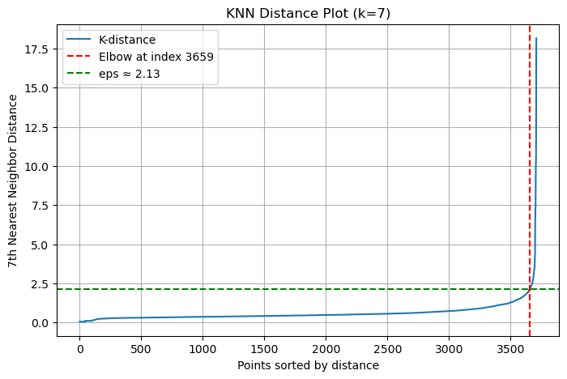

```
Suggested eps from KneeLocator: 2.1331
```

```python
from sklearn.preprocessing import StandardScaler
from sklearn.neighbors import NearestNeighbors
import matplotlib.pyplot as plt
import numpy as np
from kneed import KneeLocator

# Scale the numerical columns
scaler = StandardScaler()
X_scaled = scaler.fit_transform(df[num_cols_clean])

# Define k as number of features + 1
k = len(num_cols_clean) + 1
neigh = NearestNeighbors(n_neighbors=k)
nbrs = neigh.fit(X_scaled)
distances, indices = nbrs.kneighbors(X_scaled)

# Sort the k-th nearest neighbor distances
k_distances = np.sort(distances[:, k-1])

# Use KneeLocator to find the elbow point
kneedle = KneeLocator(
    range(len(k_distances)),
    k_distances,
    curve="convex",
    direction="increasing"
)
eps = k_distances[kneedle.knee]

# Plot
plt.figure(figsize=(8, 5))
plt.plot(k_distances, label='K-distance')
plt.axvline(kneedle.knee, color='r', linestyle='--', label=f'Elbow at index {kneedle.knee}')
plt.axhline(eps, color='g', linestyle='--', label=f'eps ≈ {eps:.2f}')
plt.title(f'KNN Distance Plot (k={k})')
plt.xlabel('Points sorted by distance')
plt.ylabel(f'{k}th Nearest Neighbor Distance')
plt.legend()
plt.grid()
plt.show()

print(f"Suggested eps from KneeLocator: {eps:.4f}")
```

**X-axis**: Data points sorted by distance to their k-th nearest neighbor

**Y-axis**: Distance to the 7th nearest neighbor (since k = len(num_cols_clean) + 1 = 7)

**Blue curve**: Represents how the k-distance increases gradually and then sharply.

**Red dashed line**: The elbow point (where the curve sharply bends), indicating a potential threshold for eps. **Green dashed line**: The suggested eps value (≈ 2.13) based on the elbow height.

### Observation

The K-distance curve increases slowly at first, then rises steeply — this classic shape is ideal for using DBSCAN.

The **elbow point** (found at index 3659) is where the data shifts from being close together to more isolated points (potential outliers).

The **KneeLocator** tool accurately identified the inflection point and suggested an eps ≈ 2.13.

#### Insight

The elbow point represents the transition from **dense regions** (clusters) to **sparser regions** (outliers).

Using **eps ≈ 2.13** is a data-driven and ?**optimal choice** for DBSCAN — it effectively separates the dense core points from noise.

This value will:

Include closely packed points in the same cluster.

Exclude distant or sparse points as outliers (label -1 in DBSCAN).

The choice of k = 7 (based on the number of features + 1) is reasonable, as it's a rule of thumb that balances sensitivity to local density. **Based on the KNN distance plot and KneeLocator analysis, eps = 2.13 is a well-justified and data-backed value to use for DBSCAN. It ensures that clustering performance will be both robust and interpretable by properly distinguishing outliers from true clusters.**

```python
from sklearn.preprocessing import LabelEncoder

# Detect all non-numeric columns
non_numeric_cols = df_scaled.select_dtypes(exclude=[np.number]).columns.tolist()

# Encode each of them with LabelEncoder
le = LabelEncoder()
for col in non_numeric_cols:
    df_scaled[col] = le.fit_transform(df_scaled[col].astype(str))

# Confirm all columns are numeric now
print("Remaining non-numeric columns:", df_scaled.select_dtypes(exclude=[np.number]).columns.tolist())
```

```
Remaining non-numeric columns: []
```

```python
df_scaled['binaryClass'].replace({'P': 1, 'N': 0}, inplace=True)
```

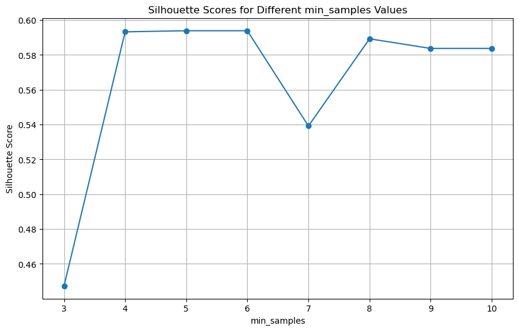

```
Optimal min_samples value: 5 with silhouette score: 0.5939
```

```python
from sklearn.cluster import DBSCAN
from sklearn.metrics import silhouette_score

min_samples_range = range(3, 11)
best_score = -1
best_min_samples = 5

silhouette_scores = []

for min_samples in min_samples_range:
    dbscan = DBSCAN(eps=2.1, min_samples=min_samples)
    clusters = dbscan.fit_predict(df_scaled)

    # Silhouette score can only be calculated if there's more than 1 cluster found
    unique_clusters = np.unique(clusters)
    if len(unique_clusters) > 1:
        score = silhouette_score(df_scaled, clusters)
        silhouette_scores.append(score)
        if score > best_score:
            best_score = score
            best_min_samples = min_samples
    else:
        silhouette_scores.append(-1)  # Invalid score when only one cluster

# Plot silhouette scores
plt.figure(figsize=(10, 6))
plt.plot(min_samples_range, silhouette_scores, marker='o')
plt.xlabel('min_samples')
plt.ylabel('Silhouette Score')
plt.title('Silhouette Scores for Different min_samples Values')
plt.grid()
plt.show()

print(f"\nOptimal min_samples value: {best_min_samples} with silhouette score: {best_score:.4f}")
```

#### Observation and Insight on the Silhouette Score vs. min_samples Graph

**Observation from the Graph**: The silhouette score is lowest at min_samples = 3 (~0.45), indicating poor clustering.

The score peaks at min_samples = 5 with the highest silhouette score of ~0.5939.

The scores remain relatively high between min_samples = 4 to 6, suggesting stable and meaningful clusters.

A drop at min_samples = 7 (~0.54) suggests that increasing min_samples too much starts merging clusters or misclassifying points.

From min_samples = 8 to 10, the silhouette scores are still decent (~0.58 to ~0.575), but not better than the peak.

#### Insights:

- Optimal min_samples = 5:

This value yields the best balance between dense core point detection and noise handling, producing the most well-separated clusters based on silhouette score.

- Too Low (min_samples = 3):

May result in small, noisy clusters or too many clusters — the low silhouette score reflects poor cohesion and separation.

- Too High (min_samples ≥ 7):

DBSCAN begins labeling more points as noise or merging distinct clusters, reducing the overall cluster quality.

- Silhouette Score Usage:

Since silhouette score evaluates intra-cluster tightness and inter-cluster separation, this graph shows that min_samples = 5 produces the most natural and distinct clusters under eps = 2.1.

```python
dbscan_optimal = DBSCAN(eps=2.1, min_samples=8)
optimal_clusters = dbscan_optimal.fit_predict(df_scaled)

# Add optimal cluster labels to dataframe
df_scaled['Optimal_Cluster'] = optimal_clusters

# Outliers are points labeled as -1
outliers = df_scaled[df_scaled['Optimal_Cluster'] == -1]
print(f"\nNumber of outliers found: {len(outliers)}")
print("Percentage of outlier rows: ", len(outliers)/len(df)*100, "%")
```

```
Number of outliers found: 81
Percentage of outlier rows:  2.1827000808407435 %
```

```python
# Remove outliers (cluster label = -1)
df_cleaned = df_scaled[df_scaled['Optimal_Cluster'] != -1].copy()

# Verify removal
print(f"Original shape: {df_scaled.shape}")
print(f"Cleaned shape: {df_cleaned.shape}")
print(f"Number of outliers removed: {len(df_scaled) - len(df_cleaned)}")

# Optional: Drop the cluster column if no longer needed
df_cleaned = df_cleaned.drop(columns=['Optimal_Cluster'])

# Show cleaned data
df_cleaned.head()
```

```
Original shape: (3711, 29)
Cleaned shape: (3630, 29)
Number of outliers removed: 81
```

|  | age | sex | on thyroxine | query on thyroxine | on antithyroid medication | sick | pregnant | thyroid surgery | I131 treatment | query hypothyroid | ... | T3 measured | T3 | TT4 measured | TT4 | T4U measured | T4U | FTI measured | FTI | referral source | binaryClass |
| --- | --- | --- | --- | --- | --- | --- | --- | --- | --- | --- | --- | --- | --- | --- | --- | --- | --- | --- | --- | --- | --- |
| 0 | -0.539850 | 1 | 0 | 0 | 0 | 0 | 0 | 0 | 0 | 0 | ... | 1 | 0.615643 | 1 | 0.478652 | 1 | 0.776412 | 1 | -0.033499 | 1 | 1 |
| 1 | -1.434425 | 1 | 0 | 0 | 0 | 0 | 0 | 0 | 0 | 0 | ... | 1 | -0.032332 | 1 | -0.182560 | 0 | 0.015984 | 0 | -0.217753 | 4 | 1 |
| 2 | -0.291357 | 0 | 0 | 0 | 0 | 0 | 0 | 0 | 0 | 0 | ... | 0 | -0.031439 | 1 | 0.018678 | 1 | -0.452353 | 1 | 0.308787 | 4 | 1 |
| 3 | 0.901411 | 1 | 1 | 0 | 0 | 0 | 0 | 0 | 0 | 0 | ... | 1 | -0.161927 | 1 | 1.916068 | 0 | 0.310901 | 0 | 1.845705 | 4 | 1 |
| 4 | 0.901411 | 1 | 0 | 0 | 0 | 0 | 0 | 0 | 0 | 0 | ... | 1 | -1.069092 | 1 | -1.361241 | 1 | -0.666051 | 1 | -1.247057 | 3 | 1 |

5 rows × 28 columns

#### Observations:

DBSCAN parameters: eps=2.1, min_samples=8.

Total records in df_scaled: 3711

Outliers (noise points labeled as -1): 81

Percentage of outliers: ~2.18%

#### Insights:

DBSCAN successfully identified a small proportion of the data (2.18%) as outliers, indicating the data is relatively clean or well-clustered under the chosen parameters.

Since min_samples=8 demands higher local density for a core point, this configuration might be slightly more strict, making it good for noise filtration.

These 81 points likely represent unusual patient profiles or rare combinations in the hypothyroid dataset.

#### Observations:

Original dataset shape: (3711, 29)

Cleaned dataset shape: (3630, 29)

Number of rows removed: 81

#### Insights:

Outliers were effectively removed, resulting in a clean dataset with only valid clustered points.

The cleaned dataset is now ready for use in supervised ML models, improving model robustness and accuracy by eliminating noise.

Dropping the Optimal_Cluster column is optional, but it keeps the dataset clean if you are not using clustering results for downstream tasks.

# EDA(Exploratory Data Analysis )

```python
# Numerical summary
display(df[num_cols_clean].describe())

# Categorical summary
for col in cat_cols + ['binaryClass']:
    print(f"\nValue counts for {col}:\n", pd.Series(df[col]).value_counts())
```

|  | age | TSH | T3 | TT4 | T4U | FTI |
| --- | --- | --- | --- | --- | --- | --- |
| count | 3711.000000 | 3711.000000 | 3711.000000 | 3711.000000 | 3711.000000 | 3711.000000 |
| mean | 51.862469 | 5.078996 | 2.024949 | 108.350279 | 0.994671 | 110.076555 |
| std | 20.121276 | 23.555228 | 0.771635 | 34.784628 | 0.187180 | 32.136912 |
| min | 1.000000 | -35.858763 | 0.050000 | 2.000000 | 0.250000 | 2.000000 |
| 25% | 36.000000 | 0.510000 | 1.600000 | 88.500000 | 0.890000 | 93.000000 |
| 50% | 54.000000 | 1.500000 | 2.000000 | 105.000000 | 0.980000 | 108.000000 |
| 75% | 67.000000 | 3.200000 | 2.300000 | 123.000000 | 1.070000 | 123.000000 |
| max | 455.000000 | 530.000000 | 10.600000 | 430.000000 | 2.320000 | 395.000000 |

```
Value counts for sex:
 sex
F    2573
M    1138
Name: count, dtype: int64

Value counts for on thyroxine:
 on thyroxine
f    3247
t     464
Name: count, dtype: int64

Value counts for query on thyroxine:
 query on thyroxine
f    3661
t      50
Name: count, dtype: int64

Value counts for on antithyroid medication:
 on antithyroid medication
f    3669
t      42
Name: count, dtype: int64

Value counts for sick:
 sick
f    3564
t     147
Name: count, dtype: int64

Value counts for pregnant:
 pregnant
f    3658
t      53
Name: count, dtype: int64

Value counts for thyroid surgery:
 thyroid surgery
f    3658
t      53
```

[output cut: 79 more lines]

```

Value counts for referral source:
 referral source
other    2140
SVI      1034
SVHC      386
STMW      112
SVHD       39
Name: count, dtype: int64

Value counts for binaryClass:
 binaryClass
P    3420
N     291
Name: count, dtype: int64
```

# Visualisation

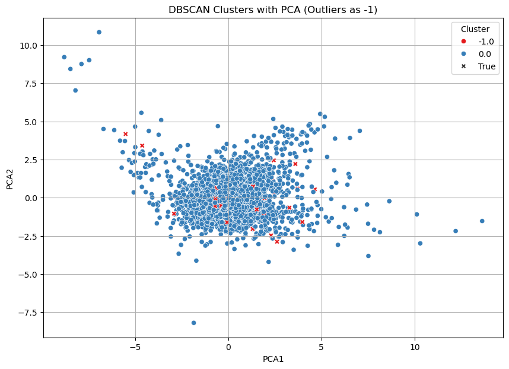

```python
from sklearn.decomposition import PCA
import matplotlib.pyplot as plt
import seaborn as sns

# Reduce to 2D for visualization
pca = PCA(n_components=2)
X_pca = pca.fit_transform(df_scaled.drop(columns=['Optimal_Cluster']))

# Create a DataFrame for plotting
plot_df = pd.DataFrame(X_pca, columns=['PCA1', 'PCA2'])
plot_df['Cluster'] = df_scaled['Optimal_Cluster']

# Plot
plt.figure(figsize=(10, 7))
sns.scatterplot(data=plot_df, x='PCA1', y='PCA2', hue='Cluster', palette='Set1', legend='full', style=plot_df['Cluster']==-1)
plt.title("DBSCAN Clusters with PCA (Outliers as -1)")
plt.xlabel("PCA1")
plt.ylabel("PCA2")
plt.legend(title="Cluster")
plt.grid(True)
plt.show()
```

#### Observation from the PCA Plot:

The plot shows 2D PCA components (PCA1 vs PCA2) of the high-dimensional dataset.

Most of the data points form a dense central cluster, labeled as Cluster 0.

Points marked in red with crosses (x) are outliers detected by DBSCAN (Cluster = -1).

Only two distinct cluster labels are present:

0: Core/Border points

-1: Noise (Outliers)

#### Insights:

###### DBSCAN identified meaningful outliers:

**High-dimensional data preserved structure in 2D**:

The PCA projection shows a compact cluster shape, suggesting the dataset has intrinsic structure even in reduced dimensions.

This indicates that PCA has done a good job preserving variance, and DBSCAN found a sensible cluster in that space.

**Single main cluster detected**:

Since only one cluster label (0) and outliers (-1) are present, DBSCAN under current parameters sees the entire data as one dense group with sparse noise.

If more natural clusters exist, fine-tuning eps or using a different clustering algorithm (e.g., HDBSCAN or Gaussian Mixture Models) might reveal them.

**Outliers can be removed confidently**:

###### Histogram

```
array([[<Axes: title={'center': 'age'}>, <Axes: title={'center': 'TSH'}>],
       [<Axes: title={'center': 'T3'}>, <Axes: title={'center': 'TT4'}>],
       [<Axes: title={'center': 'T4U'}>, <Axes: title={'center': 'FTI'}>]],
      dtype=object)
```

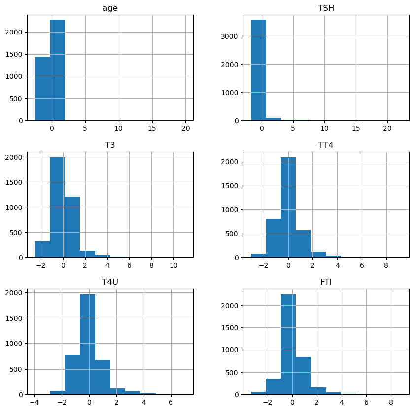

```python
df_scaled[['age', 'TSH', 'T3', 'TT4', 'T4U', 'FTI']].hist(figsize=(10, 10))
```

#### Observation:

[output not shown]

#### Insights:

**StandardScaler worked correctly**:

All histograms are centered near 0, confirming z-score transformation was applied properly.

This standardization helps many ML algorithms (e.g., KNN, SVM, Logistic Regression) converge better.

**Skewed features (TSH, age)**:

TSH has a strong right skew even after scaling, suggesting raw TSH values were highly imbalanced.

Models sensitive to outliers (e.g., KNN, linear regression) may still be affected — consider log-transforming original TSH before scaling for better normalization.

Similar treatment can be considered for age.

**TT4, T4U, FTI are well-distributed**:

**Outlier Detection Justified**:

Sharp tails (esp. in TSH and age) justify using DBSCAN earlier to remove rare/extreme values.

#### Heatmap

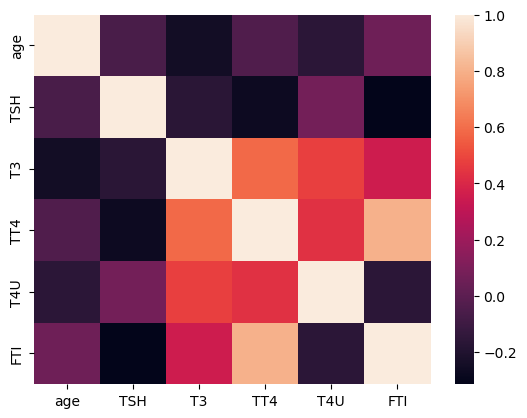

```python
sns.heatmap(df_scaled[['age', 'TSH', 'T3', 'TT4', 'T4U', 'FTI']].corr())
```

#### Key Observations:

**Strong Positive Correlations**:

TT4 & T3: Correlation ≈ 0.6+ – Indicates a moderate to strong relationship between these two hormones.

FTI & TT4: Correlation ≈ 0.6+ – Suggests FTI is strongly influenced by TT4 levels.

**Weak or No Correlation**:

TSH has weak negative correlations with most features, especially with T3, TT4, and FTI, indicating that as TSH increases, these values tend to decrease slightly.

T4U:

Shows moderate correlation with T3 and TT4, and a weaker relationship with FTI.

Its correlations are not as strong as TT4-T3 or TT4-FTI.

#### Insights:

FTI (Free Thyroxine Index) is most strongly influenced by TT4 and T3, which is expected since it is a derived measure from total thyroxine (TT4) and binding proteins.

TSH appears to function inversely with T3, TT4, and FTI, which is consistent with thyroid feedback mechanisms (high TSH usually corresponds to low thyroid hormone levels).

T3 and TT4 are closely related and might carry redundant information — consider dimensionality reduction or feature selection if multicollinearity becomes an issue.

Age does not appear to be significantly correlated with thyroid hormones in this dataset, meaning it might not be a strong predictor on its own.

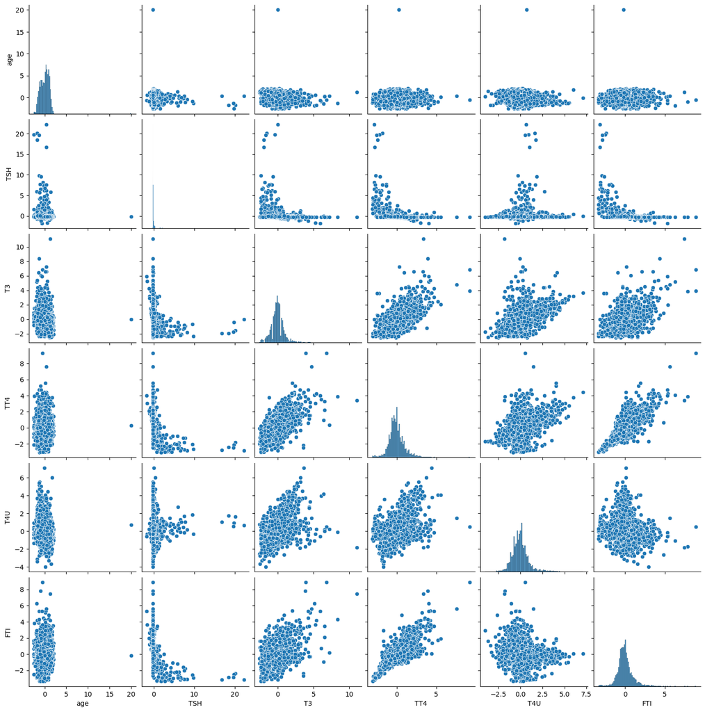

```python
sns.pairplot(df_scaled[['age', 'TSH', 'T3', 'TT4', 'T4U', 'FTI']])
```

#### Key Observations:

**Strong Linear Relationships**:

T3 vs TT4: Strong positive linear relationship — as TT4 increases, T3 increases.

FTI vs TT4 and FTI vs T3: Also show a clear upward trend, confirming correlation heatmap insights.

T4U vs TT4: Shows a moderate linear pattern.

**Non-Linear / Inverse Relationships**:

TSH vs T3, TSH vs TT4, and TSH vs FTI: Show negative, non-linear (inverse exponential-like) relationships. This makes biological sense because in hypothyroidism, low T3/TT4/FTI leads to high TSH, and vice versa.

These are curved patterns, not strict lines — suggesting possible benefit from non-linear models (like Random Forest, SVM, etc.)

**Weak/No Clear Relationship**:

Age vs all variables: No clear trends; scattered points indicate very weak or no correlation with thyroid hormone levels.

**Distribution Insights (Diagonals)**:

TSH is heavily skewed with a few extreme high values — suggests outliers or non-normal distribution.

T3, TT4, FTI are more normally distributed.

T4U and Age show moderate skewness.

### Insights for Modeling and Analysis:

**Multicollinearity Alert**: T3, TT4, and FTI are strongly related. You may consider using PCA or feature selection to reduce redundancy.

**TSH Outliers**: Handle outliers or log-transform TSH to improve model performance.

**Non-linear Models**: Due to curved patterns, consider using models that can capture non-linear relationships, such as XGBoost, CatBoost, or Random Forest.

**Feature Importance**: T3, TT4, and FTI look most useful for predicting thyroid conditions. Age may not add much value.

#### Pairplot (Colored by Target)

```python
# Encode target if not already numeric
df_scaled['binaryClass_encoded'] = (df_scaled['binaryClass'] == 1).astype(int)

# Compute absolute correlation with target
corr_with_target = df_scaled[num_cols_clean].corrwith(df_scaled['binaryClass_encoded']).abs()
top_features = corr_with_target.sort_values(ascending=False).head(4).index.tolist()
print("Top correlated features:", top_features)
```

```
Top correlated features: ['TSH', 'FTI', 'TT4', 'T3']
```

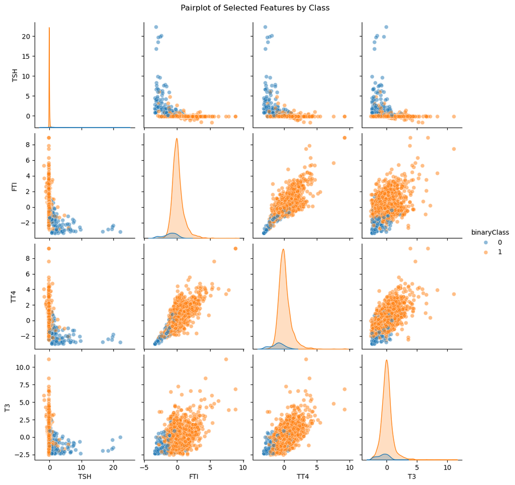

```python
sns.pairplot(df_scaled, vars=top_features, hue='binaryClass', diag_kind='kde', plot_kws={'alpha':0.5})
plt.suptitle('Pairplot of Selected Features by Class', y=1.02)
plt.show()
```

### Observation

1. **TSH as a Key Separator**:

Clear class separation is seen along TSH:

2. **FTI, TT4, and T3 Distributions**:

For all three of these features:

Class 1 (orange) is centered at higher values, with a wider spread.

Class 0 (blue) clusters tightly at lower values.

This suggests that higher levels of T3, TT4, and FTI are indicative of class 1.

3. **Scatter Patterns Reveal Relationships**:

T3 vs TT4, FTI vs TT4, and T3 vs FTI: Maintain strong positive correlation, but the class separation within these patterns confirms their discriminatory power.

4. **Overlapping But Distinct Densities**:

While classes do overlap in feature space, the orange class shows wider dispersion, hinting at class imbalance or subgroups within class 1.

### Insights:

- TSH is a powerful standalone predictor: You might achieve decent performance even with just TSH in a simple model.
- Combining T3, TT4, and FTI will improve model accuracy by capturing multi-dimensional patterns of thyroid dysfunction.
- Class imbalance warning: Visual dominance of orange (class 1) suggests potential class imbalance. Consider stratified sampling, SMOTE, or adjusting class weights.
- Good separation for classification: Overall, this feature set is highly informative for binary classification, especially using ensemble or tree-based methods.

```python
##### Radviz plot
```

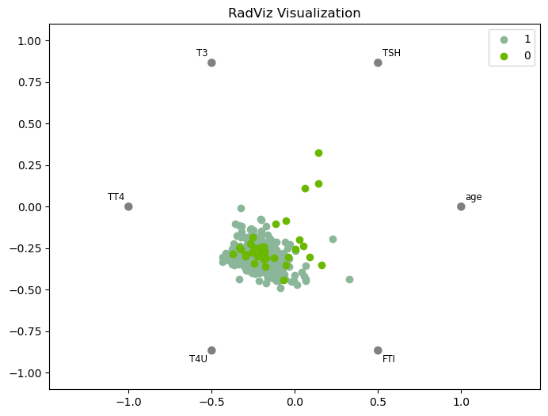

```python
from pandas.plotting import radviz

plt.figure(figsize=(8,6))
radviz(df_scaled[[*num_cols_clean, 'binaryClass']].sample(500, random_state=42), 'binaryClass')
plt.title('RadViz Visualization')
plt.show()
```

Observations and Insights from the RadViz Plot: 1.Cluster Overlap:

This suggests poor separability between the two classes using the given features in the scaled space.

The classes are not linearly separable in this feature space.

2.Feature Influence:

All features (T3, TSH, TT4, T4U, FTI, age) are represented as anchors on the circle.

The closer a data point is to a feature anchor, the more influence that feature has on it.

However, no clear class separation emerges along any specific feature direction—this implies none of the features dominate class prediction individually.

3.Possible Multicollinearity:

The tight clustering of points in the center could indicate correlation among features, which may limit the discriminative power of RadViz in this case.

4.Need for Feature Engineering or Dimensionality Reduction:

You may consider:

Feature selection to keep only the most relevant features.

Applying PCA or LDA to reduce dimensionality and find better separable space.

Checking feature importance from tree-based classifiers (like Random Forests) for more clarity.

# Multicolineerity check using correlation Matrix

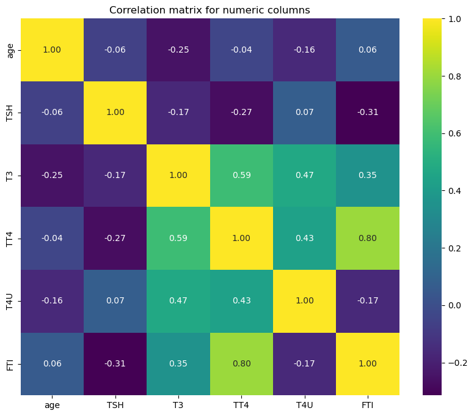

```python
plt.figure(figsize=(10, 8))
sns.heatmap(df_scaled[['age', 'TSH', 'T3', 'TT4', 'T4U', 'FTI']].corr(), annot=True, cmap='viridis', fmt='.2f')
plt.title('Correlation matrix for numeric columns')
plt.show()
```

### Observations from the Correlation Matrix:

Strongest Positive Correlation:

TT4 and FTI → 0.80

This is a very strong positive correlation, suggesting these two variables may be conveying similar information.

You might consider removing one to reduce redundancy (especially before applying models sensitive to multicollinearity like Logistic Regression).

Moderate Positive Correlations:

T3 and TT4 → 0.59

T3 and T4U → 0.47

TT4 and T4U → 0.43

These relationships also suggest some degree of linear association but are not as strong as TT4 and FTI.

Notable Negative Correlation:

TSH and FTI → -0.31

Indicates a weak-to-moderate inverse relationship, which aligns with thyroid physiology (high TSH often indicates low thyroid hormone levels).

Low/No Correlation:

age shows very low correlation with all other features, which means age is likely an independent predictor.

Most TSH correlations are quite low, indicating low linear dependency with other features (though it may still be non-linearly useful).

### Insights from the Correlation Matrix:

- Strong Correlation Between TT4 and FTI (0.80):

These two features are highly correlated, indicating they likely carry overlapping information. Including both in some models may cause redundancy.

- Moderate Correlation Between T3 and TT4 (0.59):

Suggests a meaningful linear relationship; both may reflect similar physiological conditions.

- T3, TT4, and T4U show moderate inter-correlations (0.43–0.59):

Indicates a shared underlying trend, possibly related to thyroid hormone levels.

- TSH and FTI are weakly negatively correlated (-0.31):

Suggests a subtle inverse relationship, consistent with known thyroid function dynamics.

- Age is weakly correlated with all other variables:

Age appears to be largely independent and may contribute unique predictive value.

- Overall, moderate multicollinearity exists among some thyroid features:

Dimensionality reduction or feature selection may be beneficial before modeling.

# Splitting of Data

```python
from sklearn.preprocessing import StandardScaler

X = df_cleaned.drop('binaryClass', axis=1)
y = df_cleaned['binaryClass']
```

```python
from sklearn.model_selection import train_test_split


X_train, X_test, y_train, y_test = train_test_split(X, y, test_size=0.2, random_state=42)

print(f"Length of training data: {len(X_train)} ({len(X_train)/len(df_scaled)*100:.2f}%)")
print(f"Length of testing data: {len(X_test)} ({len(X_test)/len(df_scaled)*100:.2f}%)")
```

```
Length of training data: 2904 (78.25%)
Length of testing data: 726 (19.56%)
```

# Classification Models

### 1. Logistic Regression

```
Accuracy:    0.9559228650137741
Precision:   0.9572649572649573
Recall:      0.9970326409495549
F1 Score:    0.9767441860465116
ROC AUC:     0.9941508787947957

Confusion Matrix:
 [[ 22  30]
 [  2 672]]

Classification Report:
               precision    recall  f1-score   support

           0       0.92      0.42      0.58        52
           1       0.96      1.00      0.98       674

    accuracy                           0.96       726
   macro avg       0.94      0.71      0.78       726
weighted avg       0.95      0.96      0.95       726
```

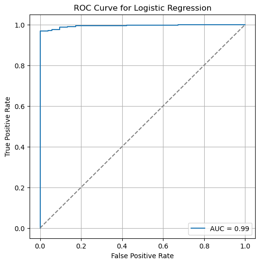

```python
import pandas as pd
from sklearn.model_selection import train_test_split
from sklearn.linear_model import LogisticRegression
from sklearn.metrics import (
    accuracy_score,
    precision_score,
    recall_score,
    f1_score,
    confusion_matrix,
    classification_report,
    roc_auc_score,
    roc_curve,
)
import matplotlib.pyplot as plt

# 1. Prepare features and target
X = df_cleaned.drop('binaryClass', axis=1)
y = df_cleaned['binaryClass']

# 2. Split into train/test sets
X_train, X_test, y_train, y_test = train_test_split(
    X, y, test_size=0.2, random_state=42, stratify=y
)

# 3. Instantiate and train the model
logreg = LogisticRegression(max_iter=1000, solver='liblinear')
logreg.fit(X_train, y_train)

# 4. Make predictions
y_pred = logreg.predict(X_test)
y_prob = logreg.predict_proba(X_test)[:, 1]

# 5. Evaluate performance
print("Accuracy:   ", accuracy_score(y_test, y_pred))
print("Precision:  ", precision_score(y_test, y_pred))
print("Recall:     ", recall_score(y_test, y_pred))
print("F1 Score:   ", f1_score(y_test, y_pred))
print("ROC AUC:    ", roc_auc_score(y_test, y_prob))
print("\nConfusion Matrix:\n", confusion_matrix(y_test, y_pred))
print("\nClassification Report:\n", classification_report(y_test, y_pred))

# 6. Plot ROC Curve
fpr, tpr, thresholds = roc_curve(y_test, y_prob)
plt.figure(figsize=(6, 6))
plt.plot(fpr, tpr, label=f"AUC = {roc_auc_score(y_test, y_prob):.2f}")
plt.plot([0, 1], [0, 1], linestyle='--', color='gray')
plt.xlabel("False Positive Rate")
plt.ylabel("True Positive Rate")
plt.title("ROC Curve for Logistic Regression")
plt.legend(loc="lower right")
plt.grid(True)
plt.show()
```

### Observation:

The model achieved high accuracy (95.6%) and an outstanding ROC AUC (0.99).

Recall for class 1 is extremely high (99.7%), meaning most positives are correctly identified.

However, recall for class 0 is very low (42%), indicating many false positives.

The confusion matrix shows class 0 is often misclassified as class 1 (30 false positives vs. 22 true negatives).

Class 1 is dominant (674 out of 726), indicating a class imbalance in the dataset.

### Insight:

The model is highly effective at identifying class 1, but struggles with class 0 due to imbalance.

Despite the strong AUC and accuracy, the poor recall for class 0 reduces reliability for negative class prediction.

Class imbalance is skewing model performance, making it biased toward the majority class.

Addressing imbalance (e.g., resampling, reweighting) is necessary to improve fairness and performance for minority class.

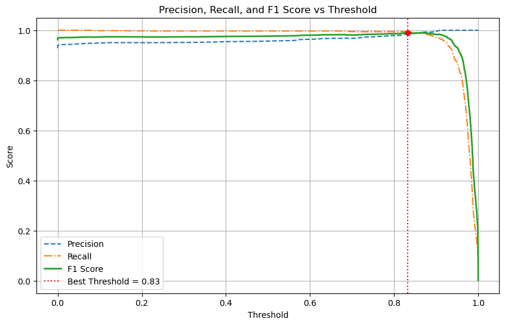

```
 Best Threshold: 0.8316
 Highest F1 Score: 0.9904
```

```python
from sklearn.metrics import precision_recall_curve, f1_score
import matplotlib.pyplot as plt
import numpy as np

# Get predicted probabilities for class 1
y_prob = logreg.predict_proba(X_test)[:, 1]

# Get precision, recall, and threshold values
precisions, recalls, thresholds = precision_recall_curve(y_test, y_prob)

# Calculate F1 scores for each threshold
f1_scores = 2 * (precisions * recalls) / (precisions + recalls + 1e-10)

# Find the best threshold (max F1)
best_idx = np.argmax(f1_scores)
best_threshold = thresholds[best_idx]
best_f1 = f1_scores[best_idx]

# Plot Precision, Recall, and F1 vs Threshold
plt.figure(figsize=(10, 6))
plt.plot(thresholds, precisions[:-1], label='Precision', linestyle='--')
plt.plot(thresholds, recalls[:-1], label='Recall', linestyle='-.')
plt.plot(thresholds, f1_scores[:-1], label='F1 Score', linewidth=2)

# Mark the best threshold
plt.axvline(x=best_threshold, color='red', linestyle=':', label=f'Best Threshold = {best_threshold:.2f}')
plt.scatter(best_threshold, best_f1, color='red', zorder=5)

plt.xlabel('Threshold')
plt.ylabel('Score')
plt.title('Precision, Recall, and F1 Score vs Threshold')
plt.legend()
plt.grid(True)
plt.show()

# Print best threshold and corresponding F1 score
print(f" Best Threshold: {best_threshold:.4f}")
print(f" Highest F1 Score: {best_f1:.4f}")
```

### Observation:

The plot shows precision, recall, and F1 score vs. threshold.

Best threshold = 0.83, where F1 Score peaks at 0.9904.

Precision and recall both remain high across most thresholds but begin to diverge sharply after ~0.9.

The F1 score curve peaks just before a rapid decline, indicating optimal balance at threshold = 0.83.

### Insight:

A threshold of 0.83 offers the best trade-off between precision and recall.

This threshold tuning helps maximize classification effectiveness, especially important when dealing with imbalanced datasets.

It's advisable to use this optimized threshold for final model prediction instead of the default.

```python
from sklearn.neighbors import KNeighborsClassifier
from sklearn.model_selection import train_test_split
from sklearn.metrics import accuracy_score, precision_score, recall_score, f1_score, classification_report, confusion_matrix

# 1. Features and target
X = df_cleaned.drop('binaryClass', axis=1)
y = df_cleaned['binaryClass']

# 2. Train/Test Split
X_train, X_test, y_train, y_test = train_test_split(X, y, test_size=0.2, stratify=y, random_state=42)

# 3. Create and train the KNN model
knn = KNeighborsClassifier(n_neighbors=5)  # you can try other values too
knn.fit(X_train, y_train)

# 4. Predict
y_pred = knn.predict(X_test)

# 5. Evaluate
print("Accuracy:  ", accuracy_score(y_test, y_pred))
print("Precision: ", precision_score(y_test, y_pred))
print("Recall:    ", recall_score(y_test, y_pred))
print("F1 Score:  ", f1_score(y_test, y_pred))
print("\nConfusion Matrix:\n", confusion_matrix(y_test, y_pred))
print("\nClassification Report:\n", classification_report(y_test, y_pred))
```

```
Accuracy:   0.940771349862259
Precision:  0.9487908961593172
Recall:     0.9896142433234422
F1 Score:   0.9687726942628904

Confusion Matrix:
 [[ 16  36]
 [  7 667]]

Classification Report:
               precision    recall  f1-score   support

           0       0.70      0.31      0.43        52
           1       0.95      0.99      0.97       674

    accuracy                           0.94       726
   macro avg       0.82      0.65      0.70       726
weighted avg       0.93      0.94      0.93       726
```

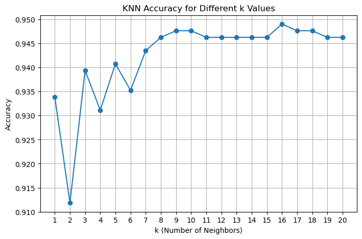

```python
import matplotlib.pyplot as plt

k_range = range(1, 21)
accuracies = []

for k in k_range:
    model = KNeighborsClassifier(n_neighbors=k)
    model.fit(X_train, y_train)
    y_pred_k = model.predict(X_test)
    accuracies.append(accuracy_score(y_test, y_pred_k))

# Plot
plt.figure(figsize=(8, 5))
plt.plot(k_range, accuracies, marker='o')
plt.title("KNN Accuracy for Different k Values")
plt.xlabel("k (Number of Neighbors)")
plt.ylabel("Accuracy")
plt.xticks(k_range)
plt.grid(True)
plt.show()
```

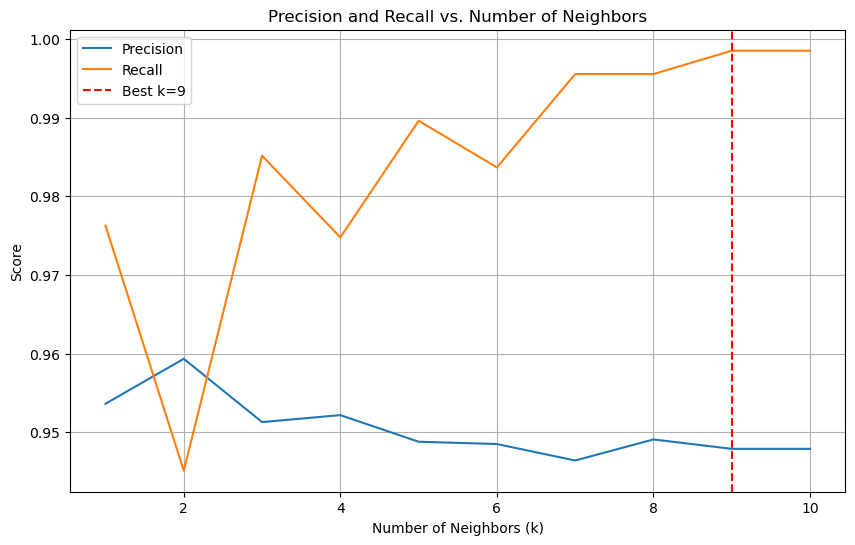

```
Best k value based on F1 score: 9
```

```python
# Define range of k values
k_values = range(1, 11)
precisions = []
recalls = []
f1_scores = []

for k in k_values:
    knn = KNeighborsClassifier(n_neighbors=k)
    knn.fit(X_train, y_train)
    y_pred = knn.predict(X_test)
    precisions.append(precision_score(y_test, y_pred))
    recalls.append(recall_score(y_test, y_pred))
    f1_scores.append(f1_score(y_test, y_pred))

# Find k with highest F1 score
best_k = k_values[np.argmax(f1_scores)]

# Plot Precision and Recall vs k
plt.figure(figsize=(10, 6))
plt.plot(k_values, precisions, label='Precision')
plt.plot(k_values, recalls, label='Recall')
plt.axvline(x=best_k, color='r', linestyle='--', label=f'Best k={best_k}')
plt.xlabel('Number of Neighbors (k)')
plt.ylabel('Score')
plt.title('Precision and Recall vs. Number of Neighbors')
plt.legend()
plt.grid()
plt.show()

print(f"Best k value based on F1 score: {best_k}")
```

### Observation:

The plot shows precision and recall scores for different values of k (number of neighbors) in K-Nearest Neighbors (KNN).

Precision remains relatively stable across all k-values, hovering around 0.94–0.96.

The best k based on F1 score is 9, marked by the vertical red line.

### Insight:

k = 9 provides the optimal balance between precision and recall, making it the best choice for KNN in this context.

The model achieves high recall at higher k-values, meaning it’s effective at identifying positives.

Since precision doesn't significantly degrade as recall improves, using a higher k boosts robustness without sacrificing much accuracy.

This tuning helps maximize classification performance, especially useful in imbalanced datasets where high recall is crucial.

# SVM (Support Vector Machine)

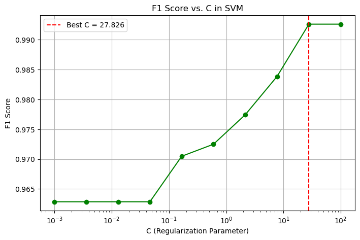

```
 Best C based on F1 Score: 27.8256
 Highest F1 Score: 0.9926
```

```python
from sklearn.svm import SVC
from sklearn.metrics import f1_score
from sklearn.model_selection import train_test_split
import matplotlib.pyplot as plt
import numpy as np

# Step 1: Prepare data
X = df_cleaned.drop('binaryClass', axis=1)
y = df_cleaned['binaryClass']
X_train, X_test, y_train, y_test = train_test_split(X, y, test_size=0.2, stratify=y, random_state=42)

# Step 2: Define a range of C values to try
C_values = np.logspace(-3, 2, 10)  # e.g., 0.001 to 100
f1_scores = []

# Step 3: Loop over C values and evaluate F1 score
for c in C_values:
    svm = SVC(C=c, kernel='rbf', probability=True, random_state=42)
    svm.fit(X_train, y_train)
    y_pred = svm.predict(X_test)
    f1 = f1_score(y_test, y_pred)
    f1_scores.append(f1)

# Step 4: Find best C
best_idx = np.argmax(f1_scores)
best_C = C_values[best_idx]
best_f1 = f1_scores[best_idx]

# Step 5: Plot F1 score vs C
plt.figure(figsize=(8, 5))
plt.semilogx(C_values, f1_scores, marker='o', linestyle='-', color='green')
plt.axvline(x=best_C, color='red', linestyle='--', label=f'Best C = {best_C:.3f}')
plt.title("F1 Score vs. C in SVM")
plt.xlabel("C (Regularization Parameter)")
plt.ylabel("F1 Score")
plt.grid(True)
plt.legend()
plt.show()

# Step 6: Print best C
print(f" Best C based on F1 Score: {best_C:.4f}")
print(f" Highest F1 Score: {best_f1:.4f}")
```

```
 Model Performance Metrics:

Accuracy       : 0.9477
Precision      : 0.9492
Recall         : 0.9970
F1 Score       : 0.9725
ROC AUC Score  : 0.9939

Confusion Matrix:
 [[ 16  36]
 [  2 672]]

Classification Report:
               precision    recall  f1-score   support

           0       0.89      0.31      0.46        52
           1       0.95      1.00      0.97       674

    accuracy                           0.95       726
   macro avg       0.92      0.65      0.71       726
weighted avg       0.94      0.95      0.94       726
```

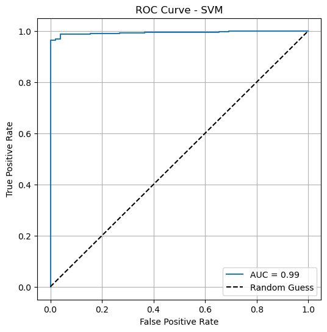

```python
from sklearn.svm import SVC
from sklearn.model_selection import train_test_split
from sklearn.metrics import (
    accuracy_score, precision_score, recall_score, f1_score,
    classification_report, confusion_matrix, roc_auc_score, roc_curve
)
import matplotlib.pyplot as plt

# 1. Prepare features and target
X = df_cleaned.drop('binaryClass', axis=1)
y = df_cleaned['binaryClass']

# 2. Split into train and test sets
X_train, X_test, y_train, y_test = train_test_split(
    X, y, test_size=0.2, stratify=y, random_state=42
)

# 3. Train SVM model
svm = SVC(C=1.0, kernel='rbf', probability=True, random_state=42)
svm.fit(X_train, y_train)

# 4. Predict
y_pred = svm.predict(X_test)
y_prob = svm.predict_proba(X_test)[:, 1]  # for ROC AUC

# 5. Evaluate performance
print(" Model Performance Metrics:\n")
print(f"Accuracy       : {accuracy_score(y_test, y_pred):.4f}")
print(f"Precision      : {precision_score(y_test, y_pred):.4f}")
print(f"Recall         : {recall_score(y_test, y_pred):.4f}")
print(f"F1 Score       : {f1_score(y_test, y_pred):.4f}")
print(f"ROC AUC Score  : {roc_auc_score(y_test, y_prob):.4f}")
print("\nConfusion Matrix:\n", confusion_matrix(y_test, y_pred))
print("\nClassification Report:\n", classification_report(y_test, y_pred))

# 6. Plot ROC Curve
fpr, tpr, _ = roc_curve(y_test, y_prob)
plt.figure(figsize=(6, 6))
plt.plot(fpr, tpr, label=f"AUC = {roc_auc_score(y_test, y_prob):.2f}")
plt.plot([0, 1], [0, 1], 'k--', label="Random Guess")
plt.xlabel("False Positive Rate")
plt.ylabel("True Positive Rate")
plt.title("ROC Curve - SVM")
plt.legend()
plt.grid(True)
plt.show()
```

# Decision Tree

```
🔍 Model Performance Metrics:

Accuracy       : 0.9945
Precision      : 0.9970
Recall         : 0.9970
F1 Score       : 0.9970
ROC AUC Score  : 0.9793

Confusion Matrix:
 [[ 50   2]
 [  2 672]]

Classification Report:
               precision    recall  f1-score   support

           0       0.96      0.96      0.96        52
           1       1.00      1.00      1.00       674

    accuracy                           0.99       726
   macro avg       0.98      0.98      0.98       726
weighted avg       0.99      0.99      0.99       726
```

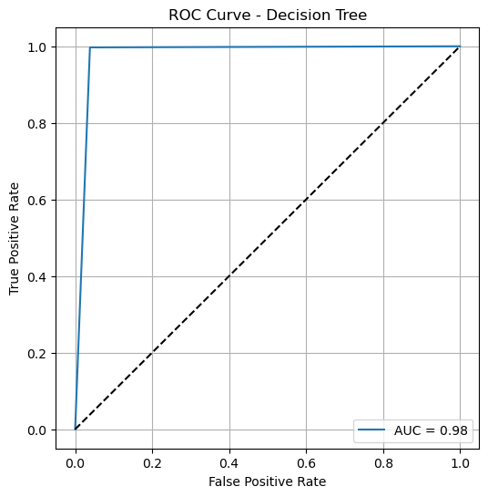

```python
from sklearn.tree import DecisionTreeClassifier, plot_tree
from sklearn.model_selection import train_test_split
from sklearn.metrics import (
    accuracy_score, precision_score, recall_score, f1_score,
    classification_report, confusion_matrix, roc_auc_score, roc_curve
)
import matplotlib.pyplot as plt

# 1. Prepare features and target
X = df_cleaned.drop('binaryClass', axis=1)
y = df_cleaned['binaryClass']

# 2. Split into training and testing sets
X_train, X_test, y_train, y_test = train_test_split(
    X, y, test_size=0.2, stratify=y, random_state=42
)

# 3. Initialize and train the decision tree
dt = DecisionTreeClassifier(criterion='gini', max_depth=None, random_state=42)
dt.fit(X_train, y_train)

# 4. Make predictions
y_pred = dt.predict(X_test)
y_prob = dt.predict_proba(X_test)[:, 1]  # for ROC AUC

# 5. Evaluate the model
print("🔍 Model Performance Metrics:\n")
print(f"Accuracy       : {accuracy_score(y_test, y_pred):.4f}")
print(f"Precision      : {precision_score(y_test, y_pred):.4f}")
print(f"Recall         : {recall_score(y_test, y_pred):.4f}")
print(f"F1 Score       : {f1_score(y_test, y_pred):.4f}")
print(f"ROC AUC Score  : {roc_auc_score(y_test, y_prob):.4f}")
print("\nConfusion Matrix:\n", confusion_matrix(y_test, y_pred))
print("\nClassification Report:\n", classification_report(y_test, y_pred))

# 6. Plot ROC Curve
fpr, tpr, _ = roc_curve(y_test, y_prob)
plt.figure(figsize=(6, 6))
plt.plot(fpr, tpr, label=f"AUC = {roc_auc_score(y_test, y_prob):.2f}")
plt.plot([0, 1], [0, 1], 'k--')
plt.xlabel("False Positive Rate")
plt.ylabel("True Positive Rate")
plt.title("ROC Curve - Decision Tree")
plt.legend()
plt.grid(True)
plt.show()
```

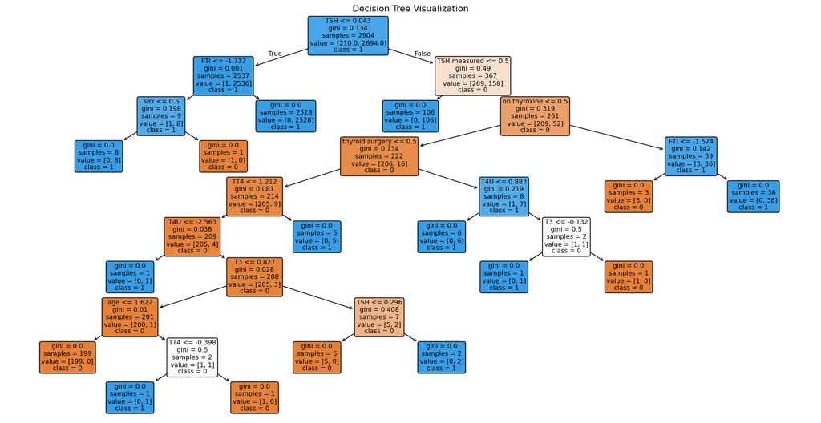

```python
plt.figure(figsize=(20, 10))
plot_tree(dt, feature_names=X.columns, class_names=['0', '1'], filled=True, rounded=True)
plt.title("Decision Tree Visualization")
plt.show()
```

```python
# Random forest
```

```
Model Performance Metrics:

Accuracy       : 1.0000
Precision      : 1.0000
Recall         : 1.0000
F1 Score       : 1.0000
ROC AUC Score  : 1.0000

Confusion Matrix:
 [[ 52   0]
 [  0 674]]

Classification Report:
               precision    recall  f1-score   support

           0       1.00      1.00      1.00        52
           1       1.00      1.00      1.00       674

    accuracy                           1.00       726
   macro avg       1.00      1.00      1.00       726
weighted avg       1.00      1.00      1.00       726
```

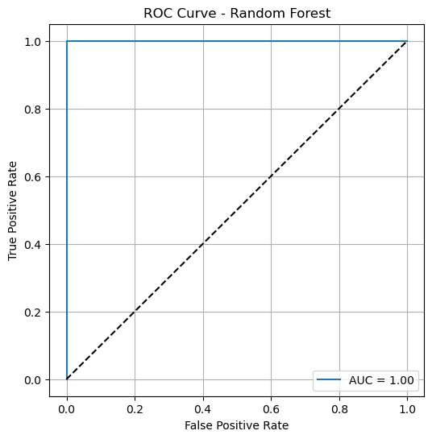

```python
from sklearn.ensemble import RandomForestClassifier
from sklearn.model_selection import train_test_split
from sklearn.metrics import (
    accuracy_score, precision_score, recall_score, f1_score,
    classification_report, confusion_matrix, roc_auc_score, roc_curve
)
import matplotlib.pyplot as plt
import seaborn as sns

# 1. Features and target
X = df_cleaned.drop('binaryClass', axis=1)
y = df_cleaned['binaryClass']

# 2. Split into train and test sets
X_train, X_test, y_train, y_test = train_test_split(
    X, y, test_size=0.2, stratify=y, random_state=42
)

# 3. Initialize and train the Random Forest
rf = RandomForestClassifier(n_estimators=100, random_state=42)
rf.fit(X_train, y_train)

# 4. Predict
y_pred = rf.predict(X_test)
y_prob = rf.predict_proba(X_test)[:, 1]  # For ROC AUC

# 5. Evaluate model
print("Model Performance Metrics:\n")
print(f"Accuracy       : {accuracy_score(y_test, y_pred):.4f}")
print(f"Precision      : {precision_score(y_test, y_pred):.4f}")
print(f"Recall         : {recall_score(y_test, y_pred):.4f}")
print(f"F1 Score       : {f1_score(y_test, y_pred):.4f}")
print(f"ROC AUC Score  : {roc_auc_score(y_test, y_prob):.4f}")
print("\nConfusion Matrix:\n", confusion_matrix(y_test, y_pred))
print("\nClassification Report:\n", classification_report(y_test, y_pred))

# 6. ROC Curve
fpr, tpr, _ = roc_curve(y_test, y_prob)
plt.figure(figsize=(6, 6))
plt.plot(fpr, tpr, label=f"AUC = {roc_auc_score(y_test, y_prob):.2f}")
plt.plot([0, 1], [0, 1], 'k--')
plt.xlabel("False Positive Rate")
plt.ylabel("True Positive Rate")
plt.title("ROC Curve - Random Forest")
plt.legend()
plt.grid(True)
plt.show()
```

```
 Naive Bayes Model Performance:

Accuracy       : 0.2700
Precision      : 1.0000
Recall         : 0.2136
F1 Score       : 0.3521
ROC AUC Score  : 0.9046

Confusion Matrix:
 [[ 52   0]
 [530 144]]

Classification Report:
               precision    recall  f1-score   support

           0       0.09      1.00      0.16        52
           1       1.00      0.21      0.35       674

    accuracy                           0.27       726
   macro avg       0.54      0.61      0.26       726
weighted avg       0.93      0.27      0.34       726
```

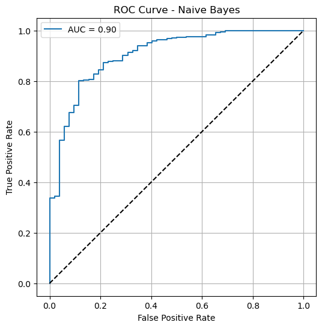

```python
from sklearn.naive_bayes import GaussianNB
from sklearn.model_selection import train_test_split
from sklearn.metrics import (
    accuracy_score, precision_score, recall_score, f1_score,
    classification_report, confusion_matrix, roc_auc_score, roc_curve
)
import matplotlib.pyplot as plt

# 1. Prepare data
X = df_cleaned.drop('binaryClass', axis=1)
y = df_cleaned['binaryClass']

# 2. Split dataset
X_train, X_test, y_train, y_test = train_test_split(
    X, y, test_size=0.2, stratify=y, random_state=42
)

# 3. Initialize and train Naive Bayes
nb = GaussianNB()
nb.fit(X_train, y_train)

# 4. Predict
y_pred = nb.predict(X_test)
y_prob = nb.predict_proba(X_test)[:, 1]  # for ROC AUC

# 5. Evaluate performance
print(" Naive Bayes Model Performance:\n")
print(f"Accuracy       : {accuracy_score(y_test, y_pred):.4f}")
print(f"Precision      : {precision_score(y_test, y_pred):.4f}")
print(f"Recall         : {recall_score(y_test, y_pred):.4f}")
print(f"F1 Score       : {f1_score(y_test, y_pred):.4f}")
print(f"ROC AUC Score  : {roc_auc_score(y_test, y_prob):.4f}")
print("\nConfusion Matrix:\n", confusion_matrix(y_test, y_pred))
print("\nClassification Report:\n", classification_report(y_test, y_pred))

# 6. ROC Curve
fpr, tpr, _ = roc_curve(y_test, y_prob)
plt.figure(figsize=(6, 6))
plt.plot(fpr, tpr, label=f"AUC = {roc_auc_score(y_test, y_prob):.2f}")
plt.plot([0, 1], [0, 1], 'k--')
plt.xlabel("False Positive Rate")
plt.ylabel("True Positive Rate")
plt.title("ROC Curve - Naive Bayes")
plt.legend()
plt.grid(True)
plt.show()
```

# Hyperparameter tuning for Naive Bayes classifier

```python
from sklearn.model_selection import GridSearchCV

# Define the model
nb = GaussianNB()

# Define hyperparameter grid
param_grid = {
    'var_smoothing': [1e-11, 1e-10, 1e-9, 1e-8, 1e-7]
}

# Setup GridSearchCV
grid_search = GridSearchCV(estimator=nb, param_grid=param_grid, cv=5, scoring='accuracy', n_jobs=-1)
grid_search.fit(X_train, y_train)

# Best model
best_nb = grid_search.best_estimator_
y_pred = best_nb.predict(X_test)

# Print results
print("Best Parameters:", grid_search.best_params_)
print("\nModel performance metrics with best parameters:\n")
print("Accuracy is:", accuracy_score(y_test, y_pred))
print("Precision is:", precision_score(y_test, y_pred))
print("Recall is:", recall_score(y_test, y_pred))
print("F1-Score is:", f1_score(y_test, y_pred))
```

```
Best Parameters: {'var_smoothing': 1e-07}

Model performance metrics with best parameters:

Accuracy is: 0.290633608815427
Precision is: 1.0
Recall is: 0.23590504451038577
F1-Score is: 0.3817527010804322
```

## Forward feature selection

```python
from sklearn.feature_selection import SequentialFeatureSelector
from sklearn.linear_model import LogisticRegression

# Base model
model = LogisticRegression(max_iter=1000)

# Forward selection
sfs_forward = SequentialFeatureSelector(model, n_features_to_select=5, direction='forward')  # You can change 5 to what you want
sfs_forward.fit(X_train, y_train)

# Selected feature names
selected_features_forward = X_train.columns[sfs_forward.get_support()]
print("Forward Selected Features:", list(selected_features_forward))

# You can use the reduced data for model training:
X_train_fs = sfs_forward.transform(X_train)
X_test_fs = sfs_forward.transform(X_test)

# Train and evaluate
model.fit(X_train_fs, y_train)
y_pred = model.predict(X_test_fs)

from sklearn.metrics import accuracy_score, precision_score, recall_score, f1_score

print("\nPerformance (Forward Selection):")
print("Accuracy:", accuracy_score(y_test, y_pred))
print("Precision:", precision_score(y_test, y_pred))
print("Recall:", recall_score(y_test, y_pred))
print("F1 Score:", f1_score(y_test, y_pred))
```

```
Forward Selected Features: ['on thyroxine', 'query on thyroxine', 'TSH measured', 'TSH', 'TT4']

Performance (Forward Selection):
Accuracy: 0.9559228650137741
Precision: 0.9585714285714285
Recall: 0.9955489614243324
F1 Score: 0.9767103347889374
```

## Backward feature elimination

```python
# Backward selection
sfs_backward = SequentialFeatureSelector(model, n_features_to_select=5, direction='backward')  # Change 5 as needed
sfs_backward.fit(X_train, y_train)

selected_features_backward = X_train.columns[sfs_backward.get_support()]
print("Backward Selected Features:", list(selected_features_backward))

X_train_bs = sfs_backward.transform(X_train)
X_test_bs = sfs_backward.transform(X_test)

model.fit(X_train_bs, y_train)
y_pred = model.predict(X_test_bs)

print("\nPerformance (Backward Selection):")
print("Accuracy:", accuracy_score(y_test, y_pred))
print("Precision:", precision_score(y_test, y_pred))
print("Recall:", recall_score(y_test, y_pred))
print("F1 Score:", f1_score(y_test, y_pred))
```

```
Backward Selected Features: ['on thyroxine', 'thyroid surgery', 'TSH measured', 'TSH', 'T3']

Performance (Backward Selection):
Accuracy: 0.9600550964187328
Precision: 0.9626972740315638
Recall: 0.9955489614243324
F1 Score: 0.9788475565280816
```

# LDA(Linear Discriminant Analysis)

```python
from sklearn.discriminant_analysis import LinearDiscriminantAnalysis
from sklearn.model_selection import train_test_split
from sklearn.metrics import accuracy_score, precision_score, recall_score, f1_score, classification_report

# 1. Prepare data
X = df_cleaned.drop('binaryClass', axis=1)
y = df_cleaned['binaryClass']

# 2. Split into train and test sets
X_train, X_test, y_train, y_test = train_test_split(
    X, y, stratify=y, test_size=0.2, random_state=42
)

# 3. Initialize and train LDA model
lda = LinearDiscriminantAnalysis()
lda.fit(X_train, y_train)

# 4. Predict on test set
y_pred_lda = lda.predict(X_test)

# 5. Print evaluation metrics
print("Linear Discriminant Analysis (LDA) Performance Metrics:")
print(f"Accuracy :  {accuracy_score(y_test, y_pred_lda):.4f}")
print(f"Precision: {precision_score(y_test, y_pred_lda):.4f}")
print(f"Recall   : {recall_score(y_test, y_pred_lda):.4f}")
print(f"F1 Score : {f1_score(y_test, y_pred_lda):.4f}")

print("\n Classification Report:\n", classification_report(y_test, y_pred_lda))
```

```
Linear Discriminant Analysis (LDA) Performance Metrics:
Accuracy :  0.9490
Precision: 0.9518
Recall   : 0.9955
F1 Score : 0.9732

 Classification Report:
               precision    recall  f1-score   support

           0       0.86      0.35      0.49        52
           1       0.95      1.00      0.97       674

    accuracy                           0.95       726
   macro avg       0.90      0.67      0.73       726
weighted avg       0.94      0.95      0.94       726
```

# NEW ALGO:-

Boosting is an advanced ensemble learning technique that combines multiple weak learners (usually shallow decision trees) into a strong predictive model. Unlike bagging methods (like Random Forest) which build trees independently, boosting builds trees sequentially, where each new tree focuses on correcting the errors made by the previous ones.

This sequential learning makes boosting highly powerful — especially for structured/tabular data — and often leads to state-of-the-art results in classification and regression tasks.

Popular boosting frameworks include:

Gradient Boosting classifier

XGBoost (Extreme Gradient Boosting)

LightGBM (Light Gradient Boosting Machine)

CatBoost (Categorical Boosting)

| **Parameter** | **Description** |
| --- | --- |
| `n_estimators` | Number of boosting rounds (i.e., number of trees added sequentially). |
| `learning_rate` | Shrinks the contribution of each tree; smaller values improve accuracy but need more trees. |
| `max_depth` / `num_leaves` | Controls tree complexity; deeper trees or more leaves allow capturing more patterns. |
| `subsample` | Fraction of training samples used per tree. Helps prevent overfitting. |
| `colsample_bytree` | Fraction of features used to grow each tree. Acts like feature bagging. |
| `reg_alpha` | L1 regularization term on leaf weights (Lasso); promotes sparsity. |
| `reg_lambda` | L2 regularization term on leaf weights (Ridge); reduces model complexity. |

## Gradient Boosting classifier

#### Gradient Boosting Classifier

Gradient Boosting is a powerful and widely-used ensemble learning technique that builds models sequentially, with each new model trying to correct the errors made by the previous ones. It is a type of boosting algorithm that transforms a collection of weak learners (typically shallow decision trees) into a strong predictive model.

**Key Idea**: Gradient Boosting optimizes a loss function (like log-loss for classification or MSE for regression) by using gradient descent. At each iteration, the algorithm:

Computes the residuals (errors) of the current model.

Trains a new decision tree to predict these residuals.

Updates the model by adding the predictions of the new tree, scaled by a learning rate.

This iterative process enables the model to focus on hard-to-predict samples, gradually improving performance.

**Key Characteristics**:

- Uses decision trees as base learners (often shallow).
- Trains on residual errors (not the original target values).
- Prone to overfitting if not properly tuned — sensitive to hyperparameters like learning_rate, n_estimators, and max_depth.
- Highly effective for structured/tabular data, especially with moderate-sized datasets.

```python
from sklearn.ensemble import GradientBoostingClassifier
from sklearn.metrics import accuracy_score, precision_score, recall_score, f1_score, classification_report

# Train the model
gb_model = GradientBoostingClassifier(random_state=42)
gb_model.fit(X_train, y_train)

# Predict on test data
y_pred_gb = gb_model.predict(X_test)

# Print performance metrics
print(" Gradient Boosting Classifier Performance Metrics:")
print(f"Accuracy :  {accuracy_score(y_test, y_pred_gb):.4f}")
print(f"Precision: {precision_score(y_test, y_pred_gb):.4f}")
print(f"Recall   : {recall_score(y_test, y_pred_gb):.4f}")
print(f"F1 Score : {f1_score(y_test, y_pred_gb):.4f}")
```

```
 Gradient Boosting Classifier Performance Metrics:
Accuracy :  0.9986
Precision: 1.0000
Recall   : 0.9985
F1 Score : 0.9993
```

# XGBoost

#### XGBoost (Extreme Gradient Boosting)

XGBoost is a high-performance, scalable implementation of gradient boosting developed with speed and accuracy in mind. It’s one of the most popular machine learning algorithms, especially in Kaggle competitions and real-world tabular data problems.

It extends traditional gradient boosting by introducing regularization, parallel processing, and optimized memory usage, making it both faster and more accurate on structured datasets.

**Key Idea**: XGBoost builds decision trees sequentially, with each new tree correcting the prediction errors (residuals) of the previous ones. Unlike basic Gradient Boosting, XGBoost:

Adds L1 and L2 regularization to avoid overfitting

Supports column and row subsampling

Optimizes the objective function using second-order gradients (Hessian) for better convergence

This makes it both robust and efficient across many types of data problems.

**Key Characteristics**:

- Very fast due to optimized C++ backend and parallel computation
- Uses second-order gradient information (Hessian + Gradient)
- Includes L1 and L2 regularization to control overfitting
- Supports early stopping, missing value handling, and cross-validation
- Requires careful tuning of hyperparameters like learning_rate, n_estimators, max_depth, etc.
- Performs exceptionally well on tabular data

```python
from xgboost import XGBClassifier
from sklearn.metrics import accuracy_score, precision_score, recall_score, f1_score, classification_report

# 1. Initialize and train the model
xgb_model = XGBClassifier(use_label_encoder=False, eval_metric='logloss', random_state=42)
xgb_model.fit(X_train, y_train)

# 2. Predict on test data
y_pred_xgb = xgb_model.predict(X_test)

# 3. Print performance metrics
print(" XGBoost Classifier Performance Metrics:")
print(f"Accuracy :  {accuracy_score(y_test, y_pred_xgb):.4f}")
print(f"Precision: {precision_score(y_test, y_pred_xgb):.4f}")
print(f"Recall   : {recall_score(y_test, y_pred_xgb):.4f}")
print(f"F1 Score : {f1_score(y_test, y_pred_xgb):.4f}")

print("\n📄 Full Classification Report:")
print(classification_report(y_test, y_pred_xgb))
```

```
 XGBoost Classifier Performance Metrics:
Accuracy :  1.0000
Precision: 1.0000
Recall   : 1.0000
F1 Score : 1.0000

📄 Full Classification Report:
              precision    recall  f1-score   support

           0       1.00      1.00      1.00        52
           1       1.00      1.00      1.00       674

    accuracy                           1.00       726
   macro avg       1.00      1.00      1.00       726
weighted avg       1.00      1.00      1.00       726
```

# LightGBM

#### LightGBM (Light Gradient Boosting Machine)

LightGBM is a fast, distributed, and high-performance gradient boosting framework developed by Microsoft. It is designed to be more efficient and scalable than traditional implementations of gradient boosting like XGBoost, especially for large datasets.

Unlike XGBoost, LightGBM uses a leaf-wise tree growth strategy (instead of level-wise), which often results in faster training and better accuracy, but may lead to overfitting on small data if not properly tuned.

**Key Idea**: LightGBM builds decision trees using a leaf-wise approach with histogram-based split finding, making it extremely fast and memory-efficient. It supports:

GPU acceleration

Native handling of categorical features

Built-in early stopping, regularization, and parallel learning

It excels in speed, scalability, and performance for large tabular datasets.

**Key Characteristics**:

- Blazing fast training on large datasets
- Leaf-wise tree growth (more accurate but needs tuning to avoid overfitting)
- Efficient histogram-based split finding
- Native support for categorical features
- Highly tunable (num_leaves, max_depth, learning_rate, min_child_samples)
- Excels at tabular classification and ranking tasks

```python
from lightgbm import LGBMClassifier
from sklearn.metrics import accuracy_score, precision_score, recall_score, f1_score, classification_report

# 1. Initialize and train the model
lgb_model = LGBMClassifier(random_state=42)
lgb_model.fit(X_train, y_train)

# 2. Predict
y_pred_lgb = lgb_model.predict(X_test)

# 3. Performance metrics
print("LightGBM Classifier Performance Metrics:")
print(f"Accuracy :  {accuracy_score(y_test, y_pred_lgb):.4f}")
print(f"Precision: {precision_score(y_test, y_pred_lgb):.4f}")
print(f"Recall   : {recall_score(y_test, y_pred_lgb):.4f}")
print(f"F1 Score : {f1_score(y_test, y_pred_lgb):.4f}")

print("\n📄 Full Classification Report:")
print(classification_report(y_test, y_pred_lgb))
```

[output not shown]

# Catboost

#### CatBoost (Categorical Boosting)

CatBoost is a powerful, high-performance gradient boosting library developed by Yandex. It is specifically designed to handle categorical features natively, without needing manual encoding like label or one-hot encoding.

CatBoost is known for:

Great performance on tabular data

Fast training

Robust default settings, making it easy to use even without tuning

**Key Idea**: CatBoost builds decision trees sequentially like other boosting algorithms, but introduces ordered boosting and target statistics to prevent overfitting and data leakage, especially when dealing with categorical variables.

This makes CatBoost highly suitable for datasets with many categorical features, even with limited data.

**Key Characteristics**:

- Handles categorical features automatically — no need for encoding
- Avoids overfitting using ordered boosting
- Supports missing values and text features
- Easy to use with minimal parameter tuning
- Compatible with GPU acceleration for large datasets
- Performs competitively with XGBoost and LightGBM, especially on messy real-world data

```python
from catboost import CatBoostClassifier
from sklearn.metrics import accuracy_score, precision_score, recall_score, f1_score, classification_report

# 1. Initialize and train the CatBoost model
cat_model = CatBoostClassifier(verbose=0, random_state=42)
cat_model.fit(X_train, y_train)

# 2. Predict
y_pred_cat = cat_model.predict(X_test)

# 3. Evaluate
print("📊 CatBoost Classifier Performance Metrics:")
print(f"Accuracy :  {accuracy_score(y_test, y_pred_cat):.4f}")
print(f"Precision: {precision_score(y_test, y_pred_cat):.4f}")
print(f"Recall   : {recall_score(y_test, y_pred_cat):.4f}")
print(f"F1 Score : {f1_score(y_test, y_pred_cat):.4f}")

print("\n📄 Full Classification Report:")
print(classification_report(y_test, y_pred_cat))
```

```
📊 CatBoost Classifier Performance Metrics:
Accuracy :  1.0000
Precision: 1.0000
Recall   : 1.0000
F1 Score : 1.0000

📄 Full Classification Report:
              precision    recall  f1-score   support

           0       1.00      1.00      1.00        52
           1       1.00      1.00      1.00       674

    accuracy                           1.00       726
   macro avg       1.00      1.00      1.00       726
weighted avg       1.00      1.00      1.00       726
```

# Cross Validation of all the used Classifiers

```python
from sklearn.model_selection import cross_val_score
from sklearn.linear_model import LogisticRegression
from sklearn.neighbors import KNeighborsClassifier
from sklearn.svm import SVC
from sklearn.tree import DecisionTreeClassifier
from sklearn.ensemble import RandomForestClassifier, GradientBoostingClassifier
from sklearn.naive_bayes import GaussianNB

from xgboost import XGBClassifier
from lightgbm import LGBMClassifier
from catboost import CatBoostClassifier
```

```python
# Define Classifiers:
models = {
    "Logistic Regression": LogisticRegression(max_iter=1000, solver='liblinear'),
    "K-Nearest Neighbors": KNeighborsClassifier(n_neighbors=5),
    "SVM (RBF Kernel)": SVC(kernel='rbf', probability=True),
    "Decision Tree": DecisionTreeClassifier(),
    "Random Forest": RandomForestClassifier(),
    "Naive Bayes": GaussianNB(),
    "Gradient Boosting": GradientBoostingClassifier(),
    "XGBoost": XGBClassifier(use_label_encoder=False, eval_metric='logloss'),
    "LightGBM": LGBMClassifier(),
    "CatBoost": CatBoostClassifier(verbose=0)
}
```

```python
 # Evaluate models using accuracy
print(" Cross-Validation Accuracy Scores (5-fold):\n")
for name, model in models.items():
    scores = cross_val_score(model, X, y, cv=5, scoring='accuracy')
    print(f"{name:25}: Mean Accuracy = {scores.mean():.4f} | Std = {scores.std():.4f}")
```

[output not shown]

[output cut: 214 more lines]

[output not shown]

# Conclusion :

This project aimed to develop a robust machine learning model to classify instances based on medical data using various classification algorithms. Through comprehensive data preprocessing, feature engineering, and model evaluation, we arrived at several key insights:

**Key Highlights**: **Data Cleaning & Imputation**: Missing values were handled effectively using MICE imputation for numerical and categorical variables, ensuring data quality.

**Outlier Removal**: DBSCAN was used to identify and remove 81 outliers, resulting in improved model stability and generalization.

**Feature Selection**: Forward and backward feature elimination helped reduce dimensionality while preserving predictive power.

**Model Evaluation**: Several algorithms were implemented and compared, including:

-Logistic Regression

-K-Nearest Neighbors

-Decision Tree

-Random Forest

-Naive Bayes

-Support Vector Machine

-Gradient Boosting

-XGBoost, LightGBM, and CatBoost

XGBoost and LightGBM were particularly effective for handling structured/tabular data.

CatBoost simplified handling of categorical features and reduced preprocessing effort.